# Data Analysis - Experiment 5

This report gives the detailed analysis on Experiment 5 on the Sensory Pre conditioning series where we aimed to analyse whether responses can be indirectly retrieved by an associated stimuli. Contrary to previous experiment where the S-S associations were two unrelated adjectives, this time we used a noun as S1 and an adjective as S2. Here are the pairs:

> Jack - bold

> Tim - fair

> Max - neat

> Ron - Calm

## Phase 2

This Phase consisted of a forced choice task which is a colour classification task. All **4** S2s were presented -

```
- calm & fair in yellow 90% of the time (valid)
- bold & neat in blue
```

**Two** associated S1s Jack (S1 with bold) and Ron (S1 with calm) were also shown in the associated colour - blue and yellow respectively.

The performances on the valid and invalid trials were assessed to check if contingencies and S-R associations were learnt.

### t tests to check for contingency learning effects

#### Reaction Time

```r
Phase2 <- dataForced %>%
  filter(Phase == 2) %>%
  group_by(PROLIFIC_PID,Validity,Condition) %>%
  summarize(RT = mean(RT_io,na.rm = TRUE),
            ER = mean(ER, na.rm = TRUE))

aov1 <- aov_ez(data = Phase2,
               id = "PROLIFIC_PID",
               dv = "RT",
               within = c("Validity","Condition"),
               anova_table = list(correction = "none",
                                  es = "pes"))
nice(aov1)
```

```
## Anova Table (Type 3 tests)
##
## Response: RT
##               Effect    df    MSE         F   pes p.value
## 1           Validity 1, 70 955.94 12.57 ***  .152   <.001
## 2          Condition 1, 70 853.11      0.10  .001    .754
## 3 Validity:Condition 1, 70 841.44      0.04 <.001    .836
## ---
## Signif. codes:  0 '***' 0.001 '**' 0.01 '*' 0.05 '+' 0.1 ' ' 1
```

```r
pander(t.test(data = Phase2, RT~Validity,alternative = "greater",subset = (Condition == "S2-R"), paired = TRUE), style = "rmarkdown", caption = "T test output for the S2-R Valid trials")
```

T test output for the S2-R Valid trials (continued below)

| Test statistic | df | P value | Alternative hypothesis |
| --- | --- | --- | --- |
| 3.712 | 70 | 0.0002045 * * * | greater |

| mean of the differences |
| --- |
| 12.29 |

```r
pander(t.test(data = Phase2, RT~Validity,alternative = "greater",subset = (Condition == "S1-R Coloured"), paired = TRUE), style = "rmarkdown", caption = "T test output for the Coloured S1-R Valid trials")
```

T test output for the Coloured S1-R Valid trials (continued below)

| Test statistic | df | P value | Alternative hypothesis |
| --- | --- | --- | --- |
| 2.18 | 70 | 0.01633 * | greater |

| mean of the differences |
| --- |
| 13.73 |

#### Error Rate

The same holds while analysing the error data for S2-R ,$t = 2.44, p < .01$ , mean difference of 2.2% but is weaker for the coloured S1-R trials, $t = .54, p = .29$

```r
## error Rate
aov1er <- aov_ez(data = Phase2,
               id = "PROLIFIC_PID",
               dv = "ER",
               within = c("Validity","Condition"),
               anova_table = list(correction = "none",
                                  es = "pes"))
nice(aov1er)
```

```
## Anova Table (Type 3 tests)
##
## Response: ER
##               Effect    df  MSE      F   pes p.value
## 1           Validity 1, 70 0.00 3.62 +  .049    .061
## 2          Condition 1, 70 0.01   0.04 <.001    .848
## 3 Validity:Condition 1, 70 0.01   0.54  .008    .466
## ---
## Signif. codes:  0 '***' 0.001 '**' 0.01 '*' 0.05 '+' 0.1 ' ' 1
```

```r
pander(t.test(data = Phase2, ER~Validity,alternative = "greater",subset = (Condition == "S2-R"), paired = TRUE), style = "rmarkdown", caption = "T test output for the S2-R Valid trials")
```

T test output for the S2-R Valid trials (continued below)

| Test statistic | df | P value | Alternative hypothesis |
| --- | --- | --- | --- |
| 2.44 | 70 | 0.008622 * * | greater |

| mean of the differences |
| --- |
| 0.0223 |

```r
pander(t.test(data = Phase2, ER~Validity,alternative = "greater",subset = (Condition == "S1-R Coloured"), paired = TRUE), style = "rmarkdown", caption = "T test output for the Coloured S1-R Valid trials")
```

T test output for the Coloured S1-R Valid trials (continued below)

| Test statistic | df | P value | Alternative hypothesis |
| --- | --- | --- | --- |
| 0.5419 | 70 | 0.2948 | greater |

| mean of the differences |
| --- |
| 0.008216 |

```r
#write_csv(file = here("data","Phase2_MC.csv"),Phase2)
```

### Plots

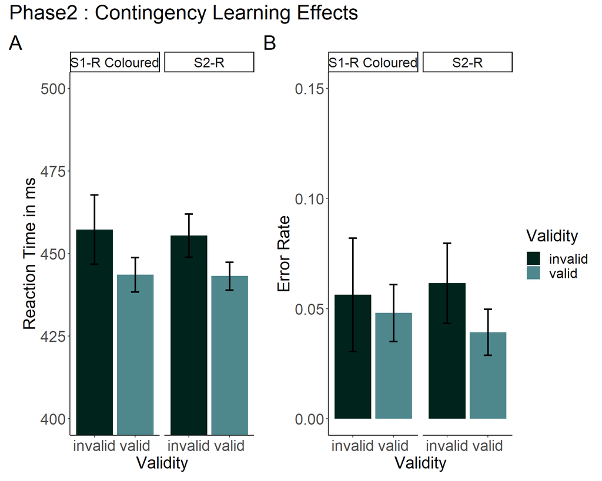

```r
meansRT <- summarySEwithin(data = Phase2, measurevar = "RT",
                           withinvars = c("Validity","Condition"),
                           idvar = "PROLIFIC_PID",
                           na.rm = TRUE,
                           conf.interval = 0.95)

plot1 <- ggplot(meansRT, aes(x=Validity, y=RT,fill = Validity))+
  geom_bar(stat = "identity",position = position_dodge())+
  geom_errorbar(aes(ymin = RT - ci, ymax =RT + ci),width = .2, size = 1,position = position_dodge(.9))+
  #scale_fill_manual(values = c("midnightblue","skyblue"))+
  coord_cartesian(ylim = c(400,500))+
  #scale_fill_paletteer_d(`"beyonce::X2"`)+
  scale_fill_manual(values = c("#00241b","#4e878c"))+
  ylab("Reaction Time in ms")+xlab("Validity")+ # or labs(x = , y =)
  facet_grid(.~Condition)


##same for ER
meansER <- summarySEwithin(data = Phase2, measurevar = "ER",
                           withinvars = c("Validity","Condition"),
                           idvar = "PROLIFIC_PID",
                           na.rm = TRUE,
                           conf.interval = 0.95)

plot2 <- ggplot(meansER, aes(x=Validity, y=ER,fill = Validity))+
  geom_bar(stat = "identity",position = position_dodge())+
  geom_errorbar(aes(ymin = ER - ci, ymax = ER + ci),width = .2, size = 1,position = position_dodge(.9))+
  #scale_fill_manual(values = c("midnightblue","skyblue"))+
  coord_cartesian(ylim = c(0,0.15))+
  #scale_fill_paletteer_d(`"beyonce::X2"`)+
  scale_fill_manual(values = c("#00241b","#4e878c"))+
  ylab("Error Rate")+xlab("Validity")+ # or labs(x = , y =)
  facet_grid(.~Condition)


Phase2Plot <- (plot1 + plot2) +
  plot_annotation(tag_levels = "A", title = "Phase2 : Contingency Learning Effects")+
  plot_layout(guides = "collect")&
  theme_classic()&
  theme(text = element_text(size = 20, family = "Times"),
        axis.text.x = element_text(size = 18),
        axis.text.y = element_text(size = 18))&
  theme(panel.background = element_rect(fill = "transparent", colour = NA),# if you want a plain background to copy to ppts
        plot.background = element_rect(fill = "transparent", colour = NA),
        legend.background = element_rect(fill = "transparent", colour = NA))

Phase2Plot
```

```r
#ggsave(filename = "Phase2_plot.png", width = 10, height = 6,Phase2Plot)
```

## Phase 3.1

This block contains a free choice task where the words appear in the neutral colour - all the S2s and S1s are shownn equal number of times and participants are asked to guess the response (colour).

The performance on the S2s and the coloured S1s will give an insight on whether participants used the learnt associations in Phase 2.

### Manipulation check for S2-R and coloured S1-R

They significantly guess better than chance level for the S2, $t = 7.09, p < .001$ with a mean of **63.8%** and for S1, $t = 15.78, p < .001$, with a mean of **66.97%**.

```r
Phase31_MCagg <- read_csv(here("data","Phase31_MC_agg.csv"))
Phase31_PC <- read_csv(here("data","Phase31_MC_PC.csv"))
Phase31_PC_valid <- Phase31_PC %>% filter(Validity=="Valid")
Phase31_MCS2_Validpc <- Phase31_PC %>%
  filter(Validity == "Valid" & Condition == "S2-R")

Phase31_MCS1_Validpc <- Phase31_PC %>%
  filter(Validity == "Valid" & Condition == "S1-R Coloured")

pander(t.test(Phase31_MCS2_Validpc$PC, mu = 0.50, alternative = "greater"), style = "rmarkdown", caption = "T test output for the S2-R Valid trials")
```

T test output for the S2-R Valid trials

| Test statistic | df | P value | Alternative hypothesis | mean of x |
| --- | --- | --- | --- | --- |
| 7.094 | 70 | 4.205e-10 * * * | greater | 0.6384 |

```r
pander(t.test(Phase31_MCS1_Validpc$PC, mu = 0.25, alternative = "greater"), style = "rmarkdown", caption = "T test output for the S1-R Coloured Valid trials")
```

T test output for the S1-R Coloured Valid trials

| Test statistic | df | P value | Alternative hypothesis | mean of x |
| --- | --- | --- | --- | --- |
| 15.78 | 70 | 4.773e-25 * * * | greater | 0.6697 |

The valid guess proportion does not differ between S2 and S1-R coloured

```r
pccomp <- aov_ez(data = Phase31_PC_valid,
                 dv = "PC",
                 id = "PROLIFIC_PID",
                 within = "Condition")
nice(pccomp)
```

```
## Anova Table (Type 3 tests)
##
## Response: PC
##      Effect    df  MSE    F  ges p.value
## 1 Condition 1, 70 0.02 1.75 .006    .191
## ---
## Signif. codes:  0 '***' 0.001 '**' 0.01 '*' 0.05 '+' 0.1 ' ' 1
```

```r
# rtcomp <- aov_ez(data = Phase31_MCagg,
#                  dv = "RT",
#                  id = "PROLIFIC_PID",
#                  within = c("Validity","Condition"))
# nice(rtcomp)
```

### Plots

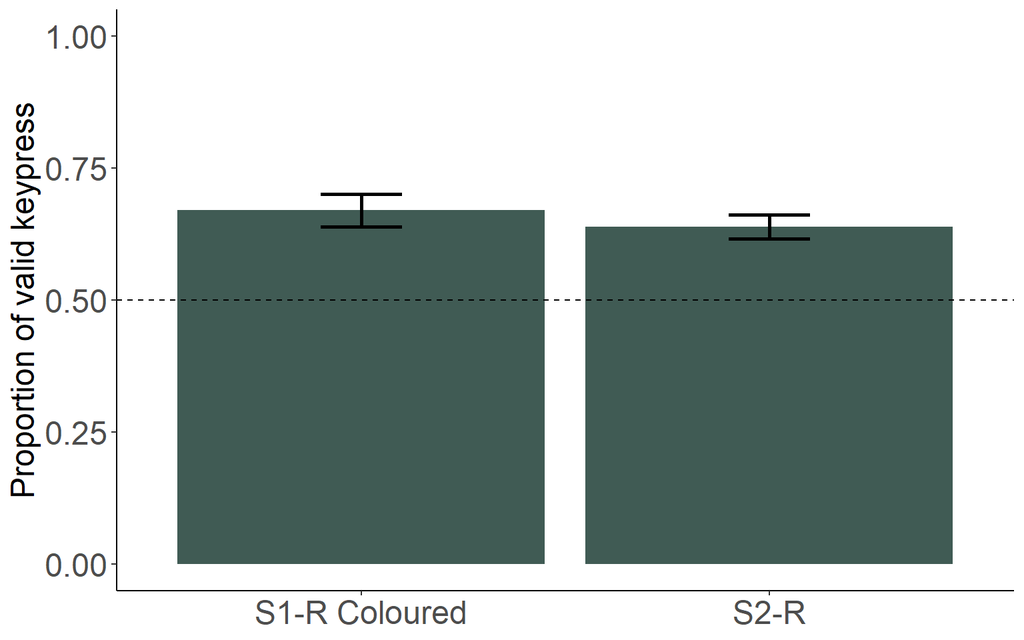

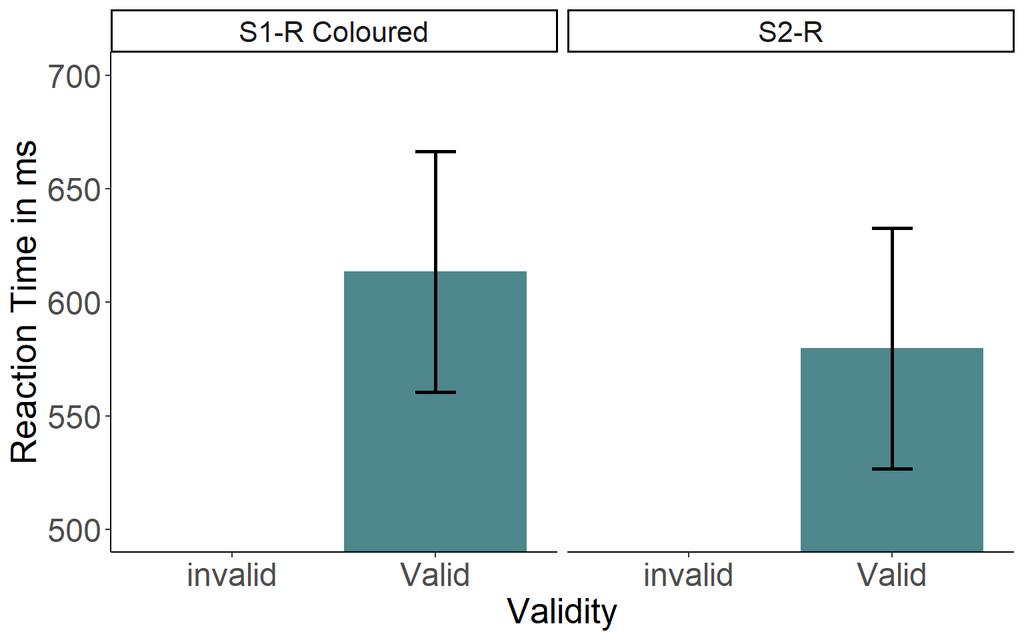

```r
mean31_PC <- summarySEwithin(data = Phase31_PC,
                           measurevar = "PC",
                           withinvars = c("Validity","Condition"),
                           idvar = "PROLIFIC_PID",
                           na.rm = TRUE,
                           conf.interval = 0.95)
mean31_PC <- mean31_PC %>% filter(Validity=="Valid")

#plots
MC31_PC <- ggplot(mean31_PC, aes(x = Condition, y = PC, fill = "midnightblue"))+
  geom_bar(alpha = 0.75, stat = "identity")+
  geom_hline(yintercept = 0.50, linetype = "dashed")+
  geom_errorbar(aes(ymin = PC - se, ymax = PC + se),width = .2, size = 1,position = position_dodge(.9))+
  #scale_fill_paletteer_d(`"beyonce::X2"`)+
  scale_fill_manual(values = c("#00241b","#4e878c"))+
  coord_cartesian(ylim = c(0,1))+
  ylab("Proportion of valid keypress")+
  xlab(NULL)+
  theme_classic()+
  theme(text = element_text(size = 18, family = "Times"),
        axis.text.x = element_text(size = 18),
        axis.text.y = element_text(size = 18),
        legend.position = "none")+
  theme(panel.background = element_rect(fill = "transparent", colour = NA),# if you want a plain background to copy to ppts
        plot.background = element_rect(fill = "transparent", colour = NA),
        legend.background = element_rect(fill = "transparent", colour = NA))
MC31_PC
#ggsave(filename = "Phase3MC_PlotPC.png",MC31_PC)

mean31RT <- summarySEwithin(data = Phase31_MCagg, measurevar = "RT",
                           withinvars = c("Validity","Condition"),
                           idvar = "PROLIFIC_PID",
                           na.rm = TRUE,
                           conf.interval = 0.95)

MC31_RT <- ggplot(mean31RT, aes(x=Validity, y=RT,fill = Validity))+
  geom_bar(stat = "identity",position = position_dodge())+
  geom_errorbar(aes(ymin = RT - ci, ymax =RT + ci),width = .2, size = 1,position = position_dodge(.9))+
  #scale_fill_manual(values = c("midnightblue","skyblue"))+
  scale_fill_manual(values = c("#00241b","#4e878c"))+
  coord_cartesian(ylim = c(500,700))+
  #scale_fill_paletteer_d(`"beyonce::X2"`)+
  ylab("Reaction Time in ms")+xlab("Validity")+ # or labs(x = , y =)
  facet_grid(.~Condition)+theme_classic()+
  theme(text = element_text(size = 20, family = "Times"),
        axis.text.x = element_text(size = 18),
        axis.text.y = element_text(size = 18),
        legend.position = "none")+
  theme(panel.background = element_rect(fill = "transparent", colour = NA),# if you want a plain background to copy to ppts
        plot.background = element_rect(fill = "transparent", colour = NA),
        legend.background = element_rect(fill = "transparent", colour = NA))
MC31_RT
#ggsave(filename = "Phase31MC_PlotRT.png",MC31_RT)
```

### Transfer Check for S1

The participants are able to significantly perform better than chance when asked to guess what response would be needed after S1.

```r
Phase31_TCagg <- read_csv(here("data","Phase31_TCagg.csv"))
Phase31_transferPC <- read_csv(here("data","Phase31_TC_PC.csv"))

Phase31_TCS1_Validpc <- Phase31_transferPC %>%
  filter(Validity=="Valid")

pander(t.test(Phase31_TCS1_Validpc$PC, mu = 0.5, alternative = "greater"), style = "rmarkdown", caption = "T test output for the S1-R Transfer Valid trials")
```

T test output for the S1-R Transfer Valid trials

| Test statistic | df | P value | Alternative hypothesis | mean of x |
| --- | --- | --- | --- | --- |
| 2.459 | 70 | 0.008205 * * | greater | 0.5493 |

```r
# rtcomp_TC <- aov_ez(data = Phase31_TCagg,
#                     dv = "RT",
#                     id = "PROLIFIC_PID",
#                     within = "Validity")
# nice(rtcomp_TC)
```

### Plots

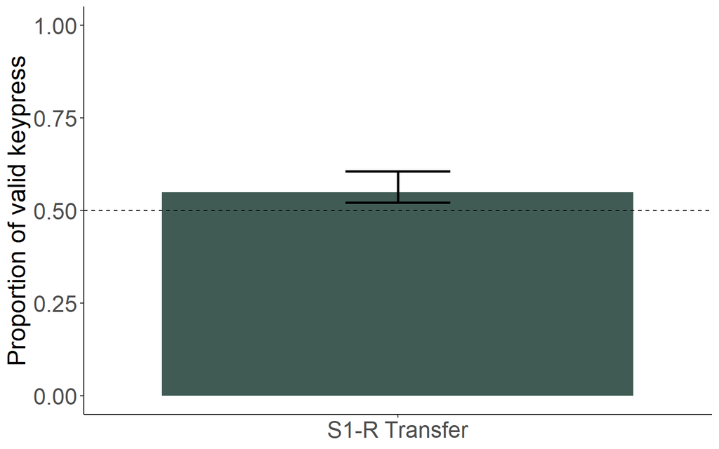

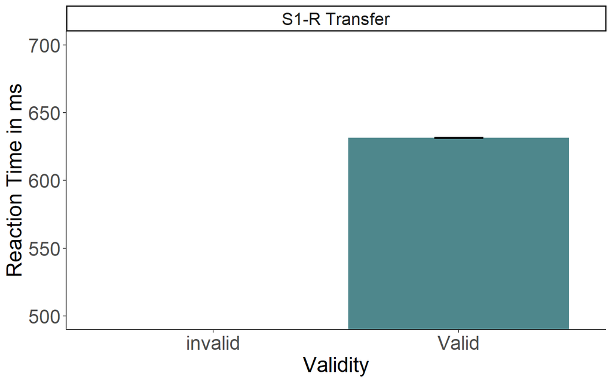

```r
mean31_TC_pc <- summarySEwithin(data = Phase31_transferPC,
                                measurevar = "PC",
                           withinvars = c("Validity","Condition"),
                           idvar = "PROLIFIC_PID",
                           na.rm = TRUE,
                           conf.interval = 0.95)
mean31_TC_pc <- mean31_TC_pc %>% filter(Validity=="Valid")
#plots
TC31_PC <- ggplot(mean31_TC_pc, aes(x = Condition,y = PC, fill = "midnightblue"))+
  geom_bar(alpha = 0.75, stat = "identity", fun = "mean")+
  geom_hline(yintercept = 0.50, linetype = "dashed")+
  geom_errorbar(aes(ymin = PC - se,ymax = PC+ci),width = .2, size = 1,position = position_dodge(.9))+
  #scale_fill_paletteer_d(`"beyonce::X2"`)+
  scale_fill_manual(values = c("#00241b","#4e878c"))+
  coord_cartesian(ylim = c(0,1))+
  ylab("Proportion of valid keypress")+
  xlab(NULL)+
  theme_classic()+
  theme(text = element_text(size = 20, family = "Times"),
        axis.text.x = element_text(size = 18),
        axis.text.y = element_text(size = 18),
        legend.position = "none")+
  theme(panel.background = element_rect(fill = "transparent", colour = NA),# if you want a plain background to copy to ppts
        plot.background = element_rect(fill = "transparent", colour = NA),
        legend.background = element_rect(fill = "transparent", colour = NA))
TC31_PC
#ggsave(filename = "Phase3TC_PC.png",TC31_PC)

mean31RT_tc <- summarySEwithin(data = Phase31_TCagg, measurevar = "RT",
                           withinvars = c("Validity","Condition"),
                           idvar = "PROLIFIC_PID",
                           na.rm = TRUE,
                           conf.interval = 0.95)

TC31_RT <- ggplot(mean31RT_tc, aes(x=Validity, y=RT,fill = Validity))+
  geom_bar(stat = "identity",position = position_dodge())+
  geom_errorbar(aes(ymin = RT - ci, ymax =RT + ci),width = .2, size = 1,position = position_dodge(.9))+
  #scale_fill_manual(values = c("midnightblue","skyblue"))+
  coord_cartesian(ylim = c(500,700))+
  scale_fill_manual(values = c("#00241b","#4e878c"))+
  #scale_fill_paletteer_d(`"beyonce::X2"`)+
  ylab("Reaction Time in ms")+xlab("Validity")+ # or labs(x = , y =)
  theme_classic()+
  facet_grid(.~Condition)+
  theme(text = element_text(size = 20, family = "Times"),
        axis.text.x = element_text(size = 18),
        axis.text.y = element_text(size = 18),
        legend.position = "none")+
  theme(panel.background = element_rect(fill = "transparent", colour = NA),# if you want a plain background to copy to ppts
        plot.background = element_rect(fill = "transparent", colour = NA),
        legend.background = element_rect(fill = "transparent", colour = NA))
TC31_RT
#ggsave(filename = "Phase3_TC_RT.png",TC31_RT)
```

## Combined Phase 3 Plots

```r
Phase31_PCall <- rbind(Phase31_PC,Phase31_transferPC)
Phase31_all_valid <- Phase31_PCall %>% filter(Validity=="Valid")

Phase31_all_valid$Condition <- factor(Phase31_all_valid$Condition, levels = c("S2-R","S1-R Coloured","S1-R Transfer"))

Phase31_all_valid <- Phase31_all_valid %>%
  mutate(Condition = recode(Condition,
                 "S1-R Coloured" = "S1 Coloured-R",
                 "S1-R Transfer" =  "S1 Transfer-R"))

table(Phase31_all_valid$Condition)
```

```
##
##          S2-R S1 Coloured-R S1 Transfer-R
##            71            71            71
```

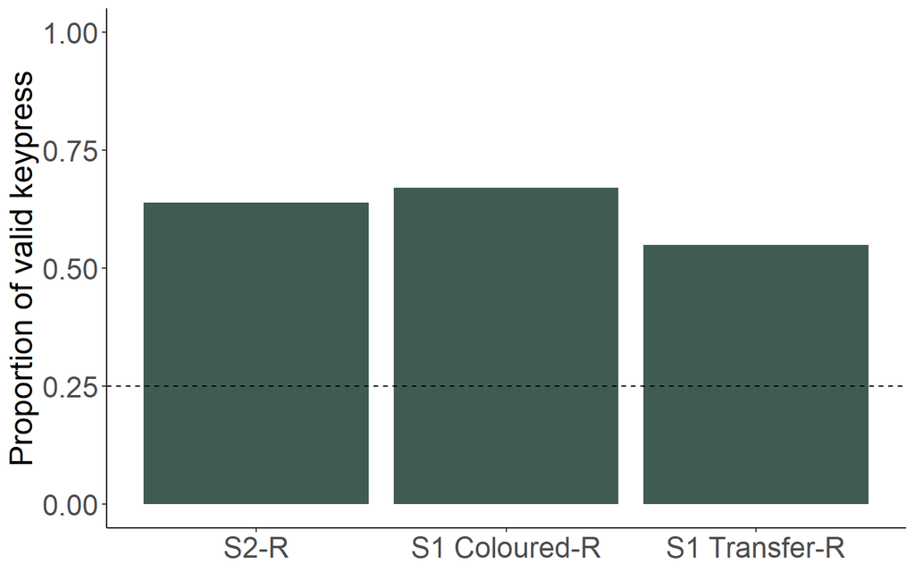

```r
Phase3_PC <- ggplot(Phase31_all_valid, aes(x = Condition,y = PC, fill = "midnightblue"))+
  geom_bar(alpha = 0.75, stat = "summary", fun = "mean")+
  geom_hline(yintercept = 0.25, linetype = "dashed")+
  #scale_fill_paletteer_d(`"beyonce::X2"`)+
  scale_fill_manual(values = c("#00241b","#4e878c"))+
  coord_cartesian(ylim = c(0,1))+
  ylab("Proportion of valid keypress")+
  xlab(NULL)+
  theme_classic()+
  theme(text = element_text(size = 20, family = "Times"),
        axis.text.x = element_text(size = 18),
        axis.text.y = element_text(size = 18),
        legend.position = "none")+
  theme(panel.background = element_rect(fill = "transparent", colour = NA),# if you want a plain background to copy to ppts
        plot.background = element_rect(fill = "transparent", colour = NA),
        legend.background = element_rect(fill = "transparent", colour = NA))

Phase3_PC
```

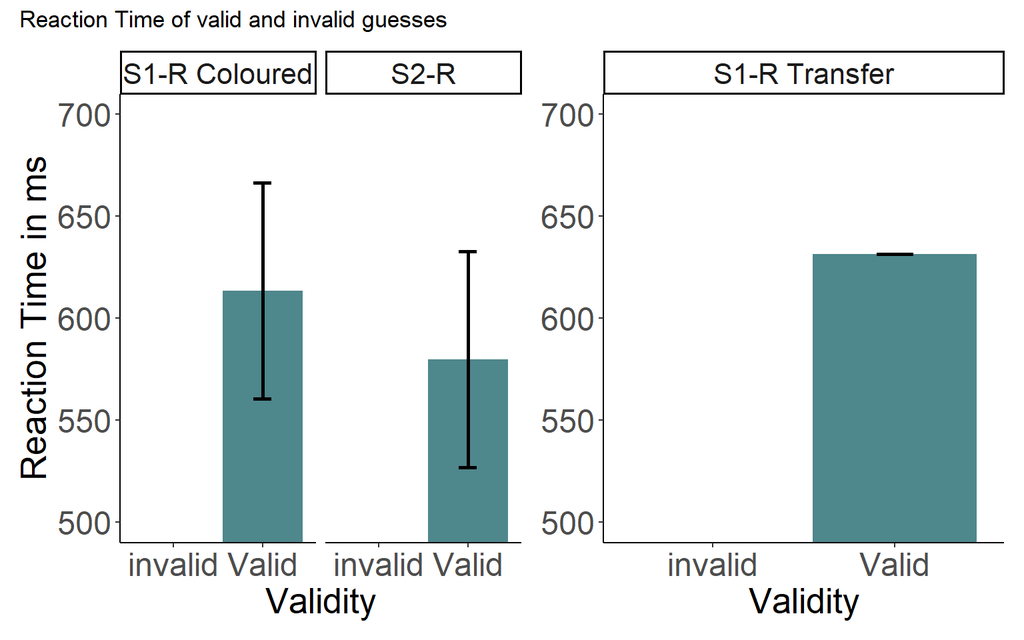

```r
ggsave(filename = "Phase3_PC.png",Phase3_PC)


Phase31_RT <- (MC31_RT+TC31_RT)&
  plot_annotation(title = "Reaction Time of valid and invalid guesses")
Phase31_RT[[2]] <- Phase31_RT[[2]]+ylab(NULL)
Phase31_RT
```

```r
#ggsave(filename = "Phase3_RT.png",Phase31_RT)
```

### Figure 2 for Experiment ms

[figure not shown]

```r
Fig2 <- (Phase2Plot/Phase3_PC)+
  plot_annotation(tag_levels = "A", title = "Experiment 2a")+
  theme_classic()&
  theme(text = element_text(size = 20, family = "Times"),
        axis.text.x = element_text(size = 18),
        axis.text.y = element_text(size = 18))&
  theme(panel.background = element_rect(fill = "transparent", colour = NA),# if you want a plain background to copy to ppts
        plot.background = element_rect(fill = "transparent", colour = NA),
        legend.background = element_rect(fill = "transparent", colour = NA))
Fig2[[2]] <- Fig2[[2]]+theme(legend.position = "none")

Fig2
```

```r
ggsave(filename = here("figures","Figure2_ms.png"),width = 12,height = 10, Fig2)
```

### ANOVA

```r
Phase31_PCall <- rbind(Phase31_PC,Phase31_transferPC)

Phase31_all_validPC <- Phase31_PCall %>%
  filter(Validity == "Valid")
## comparing the effects against each other
Ph31_PC <- aov_ez(data = Phase31_all_validPC,
                    id = "PROLIFIC_PID",
                    dv = "PC",
                    within = "Condition")
nice(Ph31_PC)
```

```
## Anova Table (Type 3 tests)
##
## Response: PC
##      Effect           df  MSE         F  ges p.value
## 1 Condition 1.86, 130.07 0.03 11.14 *** .070   <.001
## ---
## Signif. codes:  0 '***' 0.001 '**' 0.01 '*' 0.05 '+' 0.1 ' ' 1
##
## Sphericity correction method: GG
```

```r
c <- emmeans(Ph31_PC,"Condition")



#contrast(c, method = list("S2+S1Coloured - S1Transfer"=(S1.R.Coloured+S2.R)-S1.R.Transfer))
```

## Phase 3.2

### Forced CHoice Task

```r
Phase32_S2 <-  dataForced %>%
  filter(Phase == 3.2) %>%
  group_by(PROLIFIC_PID,Validity,Condition) %>%
  summarize(RT = mean(RT_io,na.rm = TRUE),
            ER = mean(ER, na.rm = TRUE))

aov2 <- aov_ez(data = Phase32_S2,
               id = "PROLIFIC_PID",
               dv = "RT",
               within = c("Validity","Condition"),
               anova_table = list(correction = "none",
                                  es = "pes"))
nice(aov2)
```

```
## Anova Table (Type 3 tests)
##
## Response: RT
##               Effect    df    MSE       F  pes p.value
## 1           Validity 1, 70 454.77    1.74 .024    .192
## 2          Condition 1, 70 520.38    0.42 .006    .521
## 3 Validity:Condition 1, 70 573.35 7.88 ** .101    .006
## ---
## Signif. codes:  0 '***' 0.001 '**' 0.01 '*' 0.05 '+' 0.1 ' ' 1
```

```r
pander(t.test(data = Phase32_S2, RT~Validity,alternative = "greater",subset = (Condition == "S2-R"), paired = TRUE), style = "rmarkdown", caption = "T test output for the S2-R Valid trials")
```

T test output for the S2-R Valid trials (continued below)

| Test statistic | df | P value | Alternative hypothesis |
| --- | --- | --- | --- |
| 4.409 | 70 | 1.832e-05 * * * | greater |

| mean of the differences |
| --- |
| 11.32 |

```r
pander(t.test(data = Phase32_S2, RT~Validity,alternative = "greater",subset = (Condition == "S1-R Coloured"), paired = TRUE), style = "rmarkdown", caption = "T test output for the Coloured S1-R Valid trials")
```

T test output for the Coloured S1-R Valid trials (continued below)

| Test statistic | df | P value | Alternative hypothesis |
| --- | --- | --- | --- |
| -0.9815 | 70 | 0.8351 | greater |

| mean of the differences |
| --- |
| -4.643 |

```r
#Error rate

aov2er <- aov_ez(data = Phase32_S2,
               id = "PROLIFIC_PID",
               dv = "ER",
               within = c("Validity","Condition"),
               anova_table = list(correction = "none",
                                  es = "pes"))
nice(aov2er)
```

```
## Anova Table (Type 3 tests)
##
## Response: ER
##               Effect    df  MSE         F  pes p.value
## 1           Validity 1, 70 0.00      0.53 .008    .469
## 2          Condition 1, 70 0.01   7.25 ** .094    .009
## 3 Validity:Condition 1, 70 0.00 12.79 *** .155   <.001
## ---
## Signif. codes:  0 '***' 0.001 '**' 0.01 '*' 0.05 '+' 0.1 ' ' 1
```

```r
pander(t.test(data = Phase32_S2,ER~Validity,alternative = "greater",subset = (Condition == "S2-R"), paired = TRUE), style = "rmarkdown", caption = "T test output for the S2-R Valid trials")
```

T test output for the S2-R Valid trials (continued below)

| Test statistic | df | P value | Alternative hypothesis |
| --- | --- | --- | --- |
| 2.954 | 70 | 0.002137 * * | greater |

| mean of the differences |
| --- |
| 0.01893 |

```r
pander(t.test(data = Phase32_S2, ER~Validity,alternative = "greater",subset = (Condition == "S1-R Coloured"), paired = TRUE), style = "rmarkdown", caption = "T test output for the Coloured S1-R Valid trials")
```

T test output for the Coloured S1-R Valid trials (continued below)

| Test statistic | df | P value | Alternative hypothesis |
| --- | --- | --- | --- |
| -2.32 | 70 | 0.9884 | greater |

| mean of the differences |
| --- |
| -0.02993 |

```r
write_csv(file = here("Data","Phase32_Forced.csv"),Phase32_S2)
```

### Free choice

```r
Phase32_TC <- dataFree %>%
  filter(Phase == "3.2") %>%
  filter(Condition == "S1-R Transfer")



Phase32_TC <- Phase32_TC %>%
  mutate(FreeChoiceResp = str_remove_all(FreeChoiceResp,"[[:punct:]]"))

table(Phase32_TC$FreeChoiceAccuracy,Phase32_TC$Condition)
```

```
##
##     S1-R Transfer
##   0          1118
##   1          1154
```

```r
table(Phase32_TC$ChkFree, Phase32_TC$Condition)
```

```
##
##     S1-R Transfer
##   0          1118
##   1          1154
```

```r
Phase32_TC <- Phase32_TC %>%
  mutate(Validity = ifelse(FreeChoiceResp == CorrectAnswer,"Valid",
                           ifelse(FreeChoiceResp != CorrectAnswer,"invalid",NA)))

#table(Phase32_TC$Validity)
Phase32_TC$Condition <- as.factor(Phase32_TC$Condition)
Phase32_TC$Validity <- as.factor(Phase32_TC$Validity)
#similar processes done in MC analysis
Phase32_TCagg <- Phase32_TC %>%
  group_by(PROLIFIC_PID,Condition,Validity, .drop = FALSE) %>%
  summarise(Freq = n())

Phase32_transferwide <- Phase32_TCagg %>%
  pivot_wider(names_from = Validity,
              values_from = Freq)
Phase32_transferwide[is.na(Phase32_transferwide)] <- 0

Phase32_transferwide <- Phase32_transferwide %>%
  mutate(ValidPC = Valid/(Valid+invalid),
         InvalidPC = invalid/(Valid +invalid))

Phase32_transferPC<- Phase32_transferwide %>%
  pivot_longer(cols = contains("PC"),
    names_to = c("Validity"),
    values_to = c("PC"))

Phase32_transferPC <- Phase32_transferPC %>%
  mutate(Validity = str_remove(Validity, "PC"),
         Validity = str_replace(Validity,"Invalid","invalid")) %>% select(-Valid,-invalid)

#Phase32_TCagg <- left_join(Phase32_TCagg,Phase32_transferPC)

transferRT_3.1 <- Phase32_TC %>%
  group_by(PROLIFIC_PID,Validity, Condition, .drop = FALSE) %>%
  summarise(RT = mean(FreeRT, na.rm=TRUE))

Phase32_TCagg <- merge(Phase32_TCagg,transferRT_3.1, by = c("PROLIFIC_PID","Validity","Condition"))

#write_csv(file = here("Data","Phase32_TCagg.csv"),Phase32_TCagg)
#write_csv(file = here("Data","Phase32_TC_PC.csv"),Phase32_transferPC)

Phase32_TCS1_Validpc <- Phase32_transferPC %>%
  filter(Validity=="Valid")

pander(t.test(Phase32_TCS1_Validpc$PC, mu = 0.5, alternative = "greater"), style = "rmarkdown", caption = "T test output for the S1-R Transfer Valid trials")
```

T test output for the S1-R Transfer Valid trials

| Test statistic | df | P value | Alternative hypothesis | mean of x |
| --- | --- | --- | --- | --- |
| 0.3744 | 70 | 0.3546 | greater | 0.5079 |

## Influence of Awareness

```r
dataAware <- read_csv(here("data","Exp5Awareness.csv"))

AwareSummary <- dataAware %>%
  group_by(PROLIFIC_PID,AwarenessType) %>%
  summarise(TotalAccuracy = sum(awarenext.corr, na.rm = TRUE))

attach(AwareSummary)
kable(table(AwarenessType,TotalAccuracy),
      format = "html",
      caption = "Acccuracy Score per Type of Awareness Questionnaire")
```

Acccuracy Score per Type of Awareness Questionnaire

|  | 0 | 1 | 2 | 3 | 4 |
| --- | --- | --- | --- | --- | --- |
| S-S Cued Recall | 1 | 4 | 11 | 18 | 37 |
| S1-R Contingency | 16 | 21 | 34 | 0 | 0 |
| S1-R Contingency-yn | 15 | 33 | 23 | 0 | 0 |
| S1-R Transfer Awareness | 21 | 27 | 23 | 0 | 0 |
| S2-R Contingency | 8 | 8 | 18 | 26 | 11 |
| S2-R Contingency-yn | 8 | 10 | 12 | 20 | 21 |

```r
## participants with awareness in the SS cued recall task
which(AwarenessType == "S-S Cued Recall" & TotalAccuracy >= 3, useNames = TRUE) -> SS_CR_aware
SS_CR_aware <- AwareSummary$PROLIFIC_PID[SS_CR_aware]

## participants awareness from S1-R transfer
S1_Q_aware <- which(AwarenessType == "S1-R Transfer Awareness" & TotalAccuracy >=1, useNames = TRUE)
S1_Q_aware <- AwareSummary$PROLIFIC_PID[S1_Q_aware]


## participants awareness of S2-R contingency
S2_Q_aware <- which(AwarenessType == "S2-R Contingency" & TotalAccuracy >= 3, useNames = TRUE)
S2_Q_aware <- AwareSummary$PROLIFIC_PID[S2_Q_aware]

#participants with S1-R coloured awareness
S1C_Q_aware <- which(AwarenessType=="S1-R Contingency" & TotalAccuracy>=1, useNames = TRUE)
S1C_Q_aware <-AwareSummary$PROLIFIC_PID[S1C_Q_aware]
detach(AwareSummary)

Phase31TC_Awareness <- Phase31_transferPC %>%
  mutate(SSCRAwareness = ifelse(PROLIFIC_PID %in% SS_CR_aware, "Aware","Unaware"),
         S1TRAwareness = ifelse(PROLIFIC_PID %in% S1_Q_aware, "Transferred","Not transferred"),
         S1CRAwareness = ifelse(PROLIFIC_PID %in% S1C_Q_aware, "Aware","Unaware"),
         S2Awareness = ifelse(PROLIFIC_PID %in% S2_Q_aware, "Aware","Unaware"))
Phase31TC_Awareness$S1TRAwareness <- factor(Phase31TC_Awareness$S1TRAwareness, levels = c("Transferred", "Not transferred"))

#write_csv(file = here("Data","Phase31TC_Awareness.csv"),Phase31TC_Awareness)
```

### Multi level modelling with awareness data

```r
Phase31_TC <- read_csv(here("data","Phase31TC_raw.csv"))

Phase31TCraw_Awareness <- Phase31_TC %>%
  mutate(SSCRAwareness = ifelse(PROLIFIC_PID %in% SS_CR_aware, "Aware","Unaware"),
         S1TRAwareness = ifelse(PROLIFIC_PID %in% S1_Q_aware, "Transferred","Not transferred"),
         S1CRAwareness = ifelse(PROLIFIC_PID %in% S1C_Q_aware, "Aware","Unaware"),
         S2Awareness = ifelse(PROLIFIC_PID %in% S2_Q_aware, "Aware","Unaware"))
Phase31TCraw_Awareness$S1TRAwareness <- factor(Phase31TCraw_Awareness$S1TRAwareness, levels = c("Transferred", "Not transferred"))

Phase31TCraw_Awareness <- Phase31TCraw_Awareness %>%
  select(PROLIFIC_PID,ChoiceType,Phase,Condition,Stim1,Stim2,Validity,FreeChoiceResp,Response.keys,FreeChoiceAccuracy,RT_io,SSCRAwareness,S1TRAwareness,S1CRAwareness,S2Awareness)

#table(Phase31TCraw_Awareness$FreeChoiceAccuracy,Phase31TCraw_Awareness$Validity)
##compute new variables - contrast coding
Phase31TCraw_Awareness <- Phase31TCraw_Awareness %>%
  mutate(SSCRAwareness = ifelse(SSCRAwareness == "Aware",1,-1),
         S2Awareness = ifelse(S2Awareness=="Aware",1,-1),
         S1CRAwareness = ifelse(S1CRAwareness=="Aware",1,-1),
         S1TRAwareness = ifelse(S1TRAwareness=="Transferred",1,-1))

#write_csv(file = here("data","DataforAwarenessMLM.csv"),Phase31TCraw_Awareness)
```

#### 1. Intercept Model with Free choice accuracy as dv

```r
m0 <- glmer(FreeChoiceAccuracy ~ 1|PROLIFIC_PID,
            data = Phase31TCraw_Awareness,
            family = binomial,
            glmerControl(optCtrl = list(maxfun = 2e5)))
```

#### 2. Model with the factors of SSAwareness and S2Awareness

```r
m1 <- glmer(data = Phase31TCraw_Awareness,
            FreeChoiceAccuracy ~ 1+SSCRAwareness + S2Awareness + (1|PROLIFIC_PID),
            family = binomial,
            glmerControl(optCtrl = list(maxfun = 2e5)))

saveRDS(m1,file = here("data","Awareness_onlymaineffects.rds"))


m1<- readRDS(file = here("data","Awareness_onlymaineffects.rds"), refhook = NULL)
tab_model(m1, show.est = T,show.se = T,show.stat = T,
          show.df = T, show.ci = F)
```

|  | FreeChoiceAccuracy |  |  |  |  |
| --- | --- | --- | --- | --- | --- |
| Predictors | Odds Ratios | std. Error | Statistic | p | df |
| (Intercept) | 1.03 | 0.10 | 0.34 | 0.738 | Inf |
| SSCRAwareness | 1.38 | 0.13 | 3.31 | **0.001** | Inf |
| S2Awareness | 1.02 | 0.08 | 0.26 | 0.794 | Inf |
| Random Effects |  |  |  |  |  |
| σ<sup>2</sup> | 3.29 |  |  |  |  |
| τ<sub>00</sub> <sub>PROLIFIC_PID</sub> | 0.24 |  |  |  |  |
| ICC | 0.07 |  |  |  |  |
| N <sub>PROLIFIC_PID</sub> | 71 |  |  |  |  |
| Observations | 1420 |  |  |  |  |
| Marginal R<sup>2</sup> / Conditional R<sup>2</sup> | 0.020 / 0.088 |  |  |  |  |

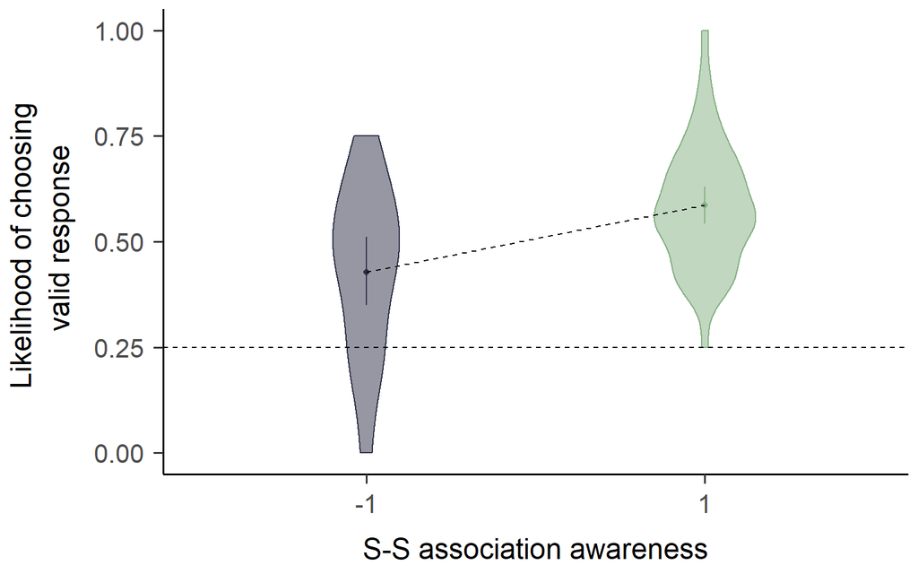

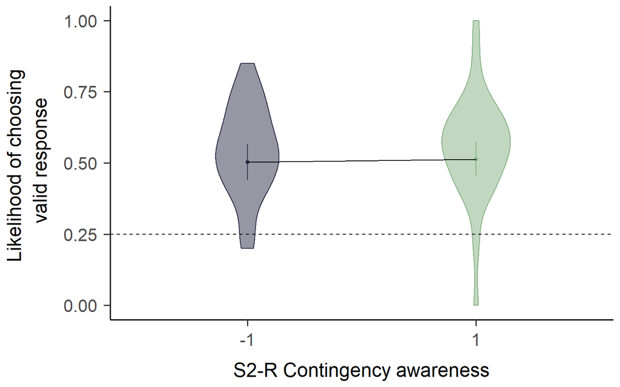

```r
afex_plot(m1, x = c("SSCRAwareness"),
          error = "model",
          data_plot = T,
          error_ci = T,
          #factor_levels = list(SSCRAwarness = c("Unaware","Aware")),
          data_geom = geom_violin,
          data_arg = list(width = 0.3),
          mapping = c("color","fill"))+
  geom_line(aes(group = 1), color = "black", linetype = "dashed")+
  geom_hline(yintercept = 0.25, linetype = "dashed")+
  theme_apa()+
  scale_y_continuous(limits = c(0,1))+
  scale_fill_manual(values = c("#2D3047","#84B082"))+
  scale_color_manual(values = c("#2D3047","#84B082"))+
  labs(x = "S-S association awareness",
       y = "Likelihood of choosing \n valid response")+
  theme(text = element_text(size = 18, family = "Times"), legend.position = "none")

afex_plot(m1, x = c("S2Awareness"),
          error = "model",
          data_plot = T,
          error_ci = T,
          #factor_levels = list(S2Awareness = c("Unaware","Aware")),
          data_geom = geom_violin,
          data_arg = list(width = 0.3),
          mapping = c("color","fill"))+
  geom_line(aes(group = 1), color = "black")+
  geom_hline(yintercept = 0.25, linetype = "dashed")+
  theme_apa()+
  scale_y_continuous(limits = c(0,1))+
  scale_fill_manual(values = c("#2D3047","#84B082"))+
  scale_color_manual(values = c("#2D3047","#84B082"))+
  labs(x = "S2-R Contingency awareness",
       y = "Likelihood of choosing \n valid response")+
  theme(text = element_text(size = 18, family = "Times"), legend.position = "none")
```

#### 3. Model 2 with the interaction

```r
m2 <- glmer(data = Phase31TCraw_Awareness,
            FreeChoiceAccuracy ~ 1+(SSCRAwareness * S2Awareness) + (1+(SSCRAwareness * S2Awareness)|PROLIFIC_PID),
            family = binomial,
            glmerControl(optCtrl = list(maxfun = 2e5)))

saveRDS(m2,file = here("data","Awareness_withinteractioneffects.rds"))

m2 <- readRDS(file = here("data","Awareness_withinteractioneffects.rds"), refhook = NULL)

tab_model(m2, show.est = T,show.se = T,show.stat = T,
          show.df = T, show.ci = F)
```

|  | FreeChoiceAccuracy |  |  |  |  |
| --- | --- | --- | --- | --- | --- |
| Predictors | Odds Ratios | std. Error | Statistic | p | df |
| (Intercept) | 1.01 | 0.13 | 0.05 | 0.962 | Inf |
| SSCRAwareness | 1.40 | 0.18 | 2.69 | **0.007** | Inf |
| S2Awareness | 0.94 | 0.12 | -0.50 | 0.616 | Inf |
| SSCRAwareness * S2Awareness | 1.14 | 0.14 | 1.07 | 0.286 | Inf |
| Random Effects |  |  |  |  |  |
| σ<sup>2</sup> | 3.29 |  |  |  |  |
| τ<sub>00</sub> <sub>PROLIFIC_PID</sub> | 0.08 |  |  |  |  |
| τ<sub>11</sub> <sub>PROLIFIC_PID.SSCRAwareness</sub> | 0.14 |  |  |  |  |
| τ<sub>11</sub> <sub>PROLIFIC_PID.S2Awareness</sub> | 0.15 |  |  |  |  |
| τ<sub>11</sub> <sub>PROLIFIC_PID.SSCRAwareness:S2Awareness</sub> | 0.02 |  |  |  |  |
| ρ<sub>01</sub> | -0.68 |  |  |  |  |
|  | 0.45 |  |  |  |  |
|  | -0.36 |  |  |  |  |
| ICC | 0.07 |  |  |  |  |
| N <sub>PROLIFIC_PID</sub> | 71 |  |  |  |  |
| Observations | 1420 |  |  |  |  |
| Marginal R<sup>2</sup> / Conditional R<sup>2</sup> | 0.026 / 0.098 |  |  |  |  |

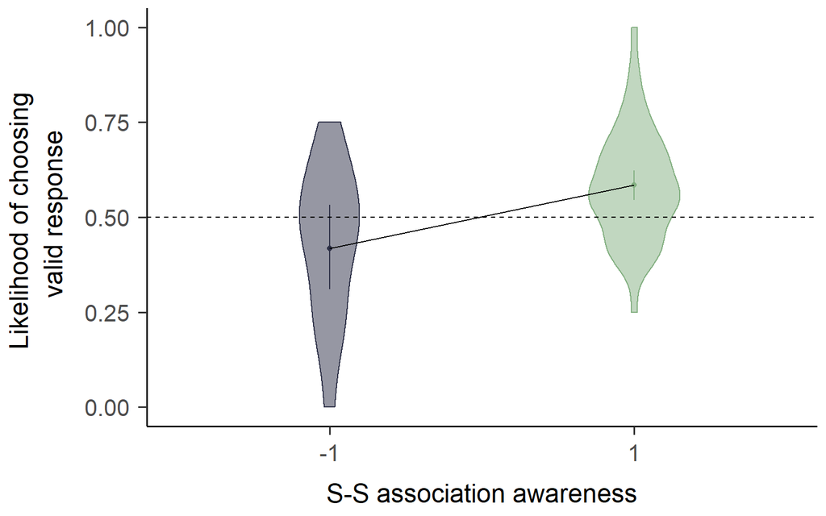

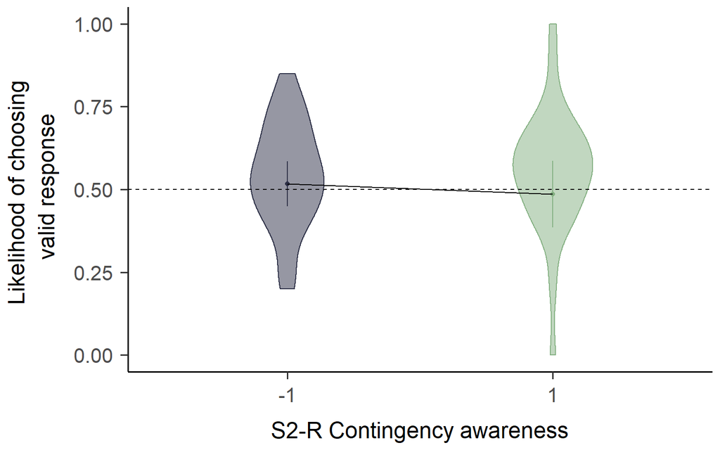

```r
afex_plot(m2, x = c("SSCRAwareness"),
          error = "model",
          data_plot = T,
          error_ci = T,
          #factor_levels = list(SSCRAwarness = c("Unaware","Aware")),
          data_geom = geom_violin,
          data_arg = list(width = 0.3),
          mapping = c("color","fill"))+
  geom_line(aes(group = 1), color = "black")+
  geom_hline(yintercept = 0.5, linetype = "dashed")+
  theme_apa()+
  scale_y_continuous(limits = c(0,1))+
  scale_fill_manual(values = c("#2D3047","#84B082"))+
  scale_color_manual(values = c("#2D3047","#84B082"))+
  labs(x = "S-S association awareness",
       y = "Likelihood of choosing \n valid response")+
  theme(text = element_text(size = 18, family = "Times"), legend.position = "none")

afex_plot(m2, x = c("S2Awareness"),
          error = "model",
          data_plot = T,
          error_ci = T,
          #factor_levels = list(S2Awareness = c("Unaware","Aware")),
          data_geom = geom_violin,
          data_arg = list(width = 0.3),
          mapping = c("color","fill"))+
  geom_line(aes(group = 1), color = "black")+
  geom_hline(yintercept = 0.5, linetype = "dashed")+
  theme_apa()+
  scale_y_continuous(limits = c(0,1))+
  scale_fill_manual(values = c("#2D3047","#84B082"))+
  scale_color_manual(values = c("#2D3047","#84B082"))+
  labs(x = "S2-R Contingency awareness",
       y = "Likelihood of choosing \n valid response")+
  theme(text = element_text(size = 18, family = "Times"), legend.position = "none")
```

### Plots showing the trends of the transfer per awareness

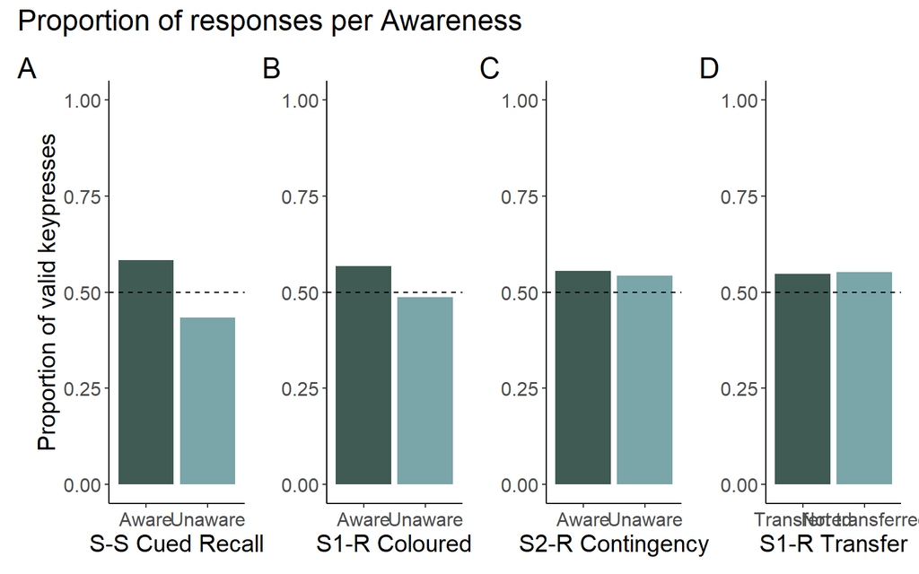

```r
Phase31_validPC_Awareness <- Phase31TC_Awareness %>%
  filter(Validity == "Valid")

ss <- ggplot(Phase31_validPC_Awareness, aes(x = SSCRAwareness,y = PC, fill = SSCRAwareness))+
  geom_bar(alpha = 0.75, stat = "summary", fun = "mean")+
  geom_hline(yintercept = 0.5, linetype = "dashed")+
  #scale_fill_paletteer_d(`"beyonce::X2"`)+
  scale_fill_manual(values = c("#00241b","#4e878c"))+
  coord_cartesian(ylim = c(0,1))+
  ylab("Proportion of valid keypress")+
  xlab("S-S Cued Recall")+
  theme_classic()+
  theme(text = element_text(size = 18),
        legend.position = "none")

s1c <- ggplot(Phase31_validPC_Awareness, aes(x = S1CRAwareness,y = PC, fill = S1CRAwareness))+
  geom_bar(alpha = 0.75, stat = "summary", fun = "mean")+
  geom_hline(yintercept = 0.5, linetype = "dashed")+
  #scale_fill_paletteer_d(`"beyonce::X2"`)+
  scale_fill_manual(values = c("#00241b","#4e878c"))+
  coord_cartesian(ylim = c(0,1))+
  ylab("Proportion of valid keypress")+
  xlab("S1-R Coloured")+
  theme_classic()+
  theme(text = element_text(size = 18),
        legend.position = "none")

s1t <- ggplot(Phase31_validPC_Awareness, aes(x = S1TRAwareness,y = PC, fill = S1TRAwareness))+
  geom_bar(alpha = 0.75, stat = "summary", fun = "mean")+
  geom_hline(yintercept = 0.5, linetype = "dashed")+
  #scale_fill_paletteer_d(`"beyonce::X2"`)+
  scale_fill_manual(values = c("#00241b","#4e878c"))+
  coord_cartesian(ylim = c(0,1))+
  ylab("Proportion of valid keypress")+
  xlab("S1-R Transfer")+
  theme_classic()+
  theme(text = element_text(size = 18),
        legend.position = "none")
s2 <- ggplot(Phase31_validPC_Awareness, aes(x = S2Awareness,y = PC, fill = S2Awareness))+
  geom_bar(alpha = 0.75, stat = "summary", fun = "mean")+
  geom_hline(yintercept = 0.5, linetype = "dashed")+
  scale_fill_manual(values = c("#00241b","#4e878c"))+
  #scale_fill_paletteer_d(`"beyonce::X2"`)+
  coord_cartesian(ylim = c(0,1))+
  ylab("Proportion of valid keypress")+
  xlab("S2-R Contingency")+
  theme_classic()+
  theme(text = element_text(size = 18),
        legend.position = "none")

awareplot <- (ss+s1c+s2+s1t)+
  plot_annotation(tag_levels = "A", title = "Proportion of responses per Awareness")+
  plot_layout(guides = "collect", nrow = 1)&theme(text = element_text(size = 15),
        axis.text.x = element_text(size = 12),
        axis.text.y = element_text(size = 12),
        legend.position = "none") +
  theme(panel.background = element_rect(fill = "transparent", colour = NA),# if you want a plain background to copy to ppts
        plot.background = element_rect(fill = "transparent", colour = NA),
        legend.background = element_rect(fill = "transparent", colour = NA))&
  ylab("Proportion of valid keypresses")
awareplot[[2]] <- awareplot[[2]] + ylab(NULL)
awareplot[[3]] <- awareplot[[3]] + ylab(NULL)
awareplot[[4]] <- awareplot[[4]] + ylab(NULL)

awareplot
```

```r
#ggsave(filename = "Awareness_abovechanceaccurate.png",awareplot,width = 18, height = 10)
```

### Tests of significance among the awareness data

```r
Phase31TC_Awareness <- Phase31TC_Awareness %>%
  filter(Validity == "Valid")

pander(t.test(data = Phase31TC_Awareness, PC~S1TRAwareness),style = "rmarkdown",caption = "Difference between aware and unaware - S1 Transfer Awarness")
s1traware <- Phase31TC_Awareness %>% filter(S1TRAwareness == "Transferred")
pander(t.test(s1traware$PC, mu=0.5),style = "rmarkdown",caption = "Valid proportion - S1TRansfer")


pander(t.test(data = Phase31TC_Awareness, PC~S2Awareness),style = "rmarkdown",caption = "Difference between aware and unaware - S2-R Awarness")
s2raware <- Phase31TC_Awareness %>% filter(S2Awareness == "Aware")
pander(t.test(s2raware$PC, mu=0.5, alternative = "greater"),style = "rmarkdown",caption = "Valid proportion - S2RTransfer")


pander(t.test(data = Phase31TC_Awareness, PC~S1CRAwareness),style = "rmarkdown",caption = "Difference between aware and unaware - S1-R Awarness")

pander(t.test(data = Phase31TC_Awareness, PC~SSCRAwareness),style = "rmarkdown",caption = "Difference between aware and unaware - S-s Awarness")
```

[output not shown]

## Binding Analyses

### 1. Prime-Probe S2 sequences

```r
Phase32_S2 <- read_csv(here("data","Phase32_S2s.csv"))

table(Phase32$TrialType)
table(Phase32$Condition)
Phase32_S2 <- Phase32_S2 %>%
  filter(TrialType == "Prime"|TrialType == "Probe")
Phase32_S2$RRel <- NA
Phase32_S2 <- Phase32_S2 %>%
  mutate(RRel = ifelse(Response.keys == lag(Response.keys,1),"RR",RRel))

Phase32_S2 <- Phase32_S2 %>%
  mutate(RRel = ifelse(Response.keys != lag(Response.keys,1) & is.na(RRel)==TRUE,"RC",RRel))
table(Phase32_S2$RRel)

Phase32_S2$SRel <- NA

Phase32_S2 <- Phase32_S2 %>%
  mutate(SRel = ifelse(Stim2 == lag(Stim2,1),"SR",SRel))

Phase32_S2 <- Phase32_S2 %>%
  mutate(SRel = ifelse(Stim2 != lag(Stim2,1) & is.na(SRel)==TRUE,"SC",SRel))
table(Phase32_S2$SRel)

Phase32_S2 <- Phase32_S2 %>% relocate(SRel,RRel,Colour)
table(Phase32$Stim2,Phase32$Colour,Phase32$PROLIFIC_PID)
Phase32_S2 <- Phase32_S2 %>%
  filter(ACC_trials==1)
table(Phase32_S2$SRel,Phase32_S2$RRel)


## create an agg file
Phase32_S2_agg <- Phase32_S2 %>%
  group_by(PROLIFIC_PID,SRel,RRel) %>%
  summarise(RT = mean(AllRT,na.rm=TRUE)) %>% drop_na()


ggplot(Phase32_S2_agg, aes(x=RRel,y=RT, color = SRel, fill = SRel))+
  geom_line(aes(group=SRel, linetype = SRel), size = 1, stat="summary", fun = "mean")+
  geom_point(aes(shape = SRel), size = 3, stat = "summary", fun = "mean")+
  labs(x="Response Relation",
       y = "Reaction Time",
       color = "Stimulus Relation",
       fill = "Stimulus Relation",
       linetype = "Stimulus Relation",
       shape = "Stimulus Relation")+
  theme_classic()+
  coord_cartesian(ylim = c(400,500))+
  scale_color_paletteer_d(`"beyonce::X3"`)+
  scale_fill_paletteer_d(`"beyonce::X3"`)+
  theme(text = element_text(size = 18, family = "Times"))
  #scale_color_manual(values = c("#6E9887","#A4D4B4","#073B3A","#B2B09B"))
```

#### ANOVA

```r
s2binding <- aov_ez(data = Phase32_S2_agg,
                    id = "PROLIFIC_PID",
                    dv = "RT",
                    within = c("SRel","RRel"))
nice(s2binding)
```

[output not shown]

#### Multi level model

```r
mlm_s2 <- Phase32_S2
mlm_s2 <- mlm_s2 %>%
  mutate(previous_rm  = ifelse(RRel == "RR",1,2),
         Stim_rm = ifelse(SRel == "SR",1,2))

means.previous_rm <- aggregate(data = mlm_s2, previous_rm ~ PROLIFIC_PID, mean)

names(means.previous_rm)[2]<-"previous_rm_mean"

mlm_s2<-merge (mlm_s2, means.previous_rm, by="PROLIFIC_PID")

mlm_s2$previous_rm_cwp <- mlm_s2$previous_rm-mlm_s2$previous_rm_mean
summary(mlm_s2$previous_rm_cwp)


model0 <- lmer(AllRT~1+SRel*RRel + (1+SRel*RRel|PROLIFIC_PID),
                      data=mlm_s2,
                      REML=F,
                      na.action = "na.omit")
tab_model(model0, show.se = TRUE,show.stat = TRUE, show.ci = FALSE,show.aic = TRUE, show.loglik = TRUE,
                  dv.labels = "Reaction Time")

plot_model(model0, type = "pred", terms = c("RRel","SRel"))
```

### 2. Prime-Probe with S1-Transfer as Probes

```r
Phase32all <- read_csv(here("data","Phase32_combined.csv"))

Phase32_SRB <- Phase32all %>%
  filter(TrialType == "Prime" | TrialType == "Probe")

table(Phase32_SRB$TrialType,Phase32_SRB$ACC_trials)
# There are 67 trials where prime was incorrect
Phase32_SRB <- Phase32_SRB %>%
  mutate(PrimeAcc = case_when(TrialType=="Prime"&ACC_trials==0~"Incorrect Prime"))
Phase32_SRB <- Phase32_SRB %>%
  mutate(PrimeAcc = ifelse(TrialType=="Probe"&lag(PrimeAcc,1)=="Incorrect Prime","Invalid Probe",PrimeAcc))

#table(Phase32_SRB$PrimeAcc)

#removing unusable PRime-Probe sequences
Phase32_SRB <- Phase32_SRB %>%
  filter(is.na(PrimeAcc)==TRUE)

#ResponseRelation
Phase32_SRB <- Phase32_SRB %>%
  mutate(RGuess = ifelse((TrialType=="Probe" & Response.keys==lag(Response.keys,1)),"RR",
                       ifelse((TrialType == "Probe" & Response.keys != lag(Response.keys,1)),"RC",NA)))
#table(Phase32_SRB$Condition)

Phase32_SRB <- Phase32_SRB %>%
  mutate(SRel = ifelse(TrialType=="Probe"& ((Stim1 == "Tim" & lag(Stim2,1)=="fair") | (Stim1=="Max" & lag(Stim2,1)=="neat")),"Associated",
                    ifelse(TrialType=="Probe"& ((Stim1 == "Tim" & lag(Stim2,1)=="neat") | (Stim1=="Max" & (lag(Stim2,1)=="fair"))),"Not Associated",NA)))


Phase32_SRBmlm <- Phase32_SRB %>% relocate(RGuess,SRel) %>%
  filter(SRel == "Associated"|SRel == "Not Associated")

Phase32_SRBmlm <- Phase32_SRBmlm %>%
  mutate(RGuess_dicho = ifelse(RGuess=="RR",1,
         ifelse(RGuess == "RC",0,RGuess)))
table(Phase32_SRBmlm$RGuess,Phase32_SRBmlm$RGuess_dicho)


## finding the number of Trials
SRBTrialscount <- Phase32_SRB %>% group_by(PROLIFIC_PID) %>% filter(TrialType=="Probe") %>% count()

SRBtrialPerSRel <- Phase32_SRB %>%
  group_by(PROLIFIC_PID,SRel) %>%
  filter(TrialType=="Probe") %>%
  count() %>%
  drop_na(SRel)

SRBSRel_wide <- SRBtrialPerSRel %>%
  pivot_wider(id_cols = PROLIFIC_PID,
              names_from = SRel,
              values_from = n)

Phase32_PC <- Phase32_SRB %>%
  group_by(PROLIFIC_PID,SRel,RGuess, .drop = FALSE) %>%
  summarise(Freq = n(),
            RT = mean(AllRT,na.rm = TRUE)) %>% drop_na(SRel)

Phase32_wide <- Phase32_PC %>%
  pivot_wider(id_cols = PROLIFIC_PID,
              names_from = c("RGuess","SRel"),
              names_sep = "_",
              values_from = Freq)

Phase32_wide <- left_join(Phase32_wide,SRBSRel_wide)

Phase32_wide <- Phase32_wide %>%
  mutate(RC_Not_perc = (`RC_Not Associated`/`Not Associated`)*100,
         RR_Not_perc = (`RR_Not Associated`/`Not Associated`)*100,
         RR_A_perc = (`RR_Associated`/Associated)*100,
         RC_A_perc = (RC_Associated/Associated)*100)

Phase32_long <- Phase32_wide %>%
  pivot_longer(cols = contains("perc"),
               names_to = c("RGuess","SRel"),
               names_sep = "_",
               values_to = "Perc")

Phase32_long <- Phase32_long %>%
  mutate(SRel = recode(SRel, Not = "Not Associated",
                             A = "Associated"))

Phase32_dv <- left_join(Phase32_PC,Phase32_long)
Phase32_dv<-Phase32_dv %>%
  select(PROLIFIC_PID,RGuess,SRel,Freq,RT,Perc)

RespRepeat <- Phase32_dv %>% filter(RGuess == "RR")


SRBPlot_F <- ggplot(RespRepeat, aes(x=SRel,y=Perc, color = SRel, fill = SRel))+
  geom_line(aes(group=1), size = 1, stat="summary", fun = "mean")+
  geom_point(aes(shape = SRel), size = 3, stat = "summary", fun = "mean")+
  labs(x="Stimulus Relation",
       y = "Frequency % of \n Guessing previous response",
       color = "Stimulus Relation",
       fill = "Stimulus Relation",
       linetype = "Stimulus Relation",
       shape = "Stimulus Relation")+
  theme_classic()+
  coord_cartesian(ylim = c(50,60))+
  scale_color_paletteer_d(`"beyonce::X3"`)+
  scale_fill_paletteer_d(`"beyonce::X3"`)+
  theme(text = element_text(size = 18, family = "Times"))
  #scale_color_manual(values = c("#6E9887","#A4D4B4","#073B3A","#B2B09B"))
SRBPlot_F

SRBPlot_RT <- ggplot(RespRepeat,aes(x=SRel,y=RT, fill = SRel,color = SRel))+
  geom_bar(stat = "summary", fun = "mean", aes(fill = SRel,color = SRel))+
  #geom_line(aes(group=1), size = 1, stat="summary", fun = "mean")+
  #geom_point(aes(shape = SRel), size = 3, stat = "summary", fun = "mean")+
  labs(x="Stimulus Relation",
       y = "Reaction Time",
       color = "Stimulus Relation",
       fill = "Stimulus Relation",
       linetype = "Stimulus Relation",
       shape = "Stimulus Relation")+
  theme_classic()+
  scale_fill_paletteer_d(`"beyonce::X2"`)+
  scale_color_paletteer_d(`"beyonce::X2"`)+
  coord_cartesian(ylim = c(550,700))+
  theme(text = element_text(size = 18,family = "Times"))
  #scale_color_manual(values = c("#6E9887","#A4D4B4","#073B3A","#B2B09B"))
SRBPlot_RT
```

#### ANOVAs

```r
RespRepeat$SRel <- as.factor(RespRepeat$SRel)
Ph32_Perc <- aov_ez(data = RespRepeat,
                    id = "PROLIFIC_PID",
                    dv = "Perc",
                    within = "SRel")
nice(Ph32_Perc)
emmeans(Ph32_Perc,"SRel", contr = "pairwise")

Ph32_RT <- aov_ez(data = RespRepeat,
                    id = "PROLIFIC_PID",
                    dv = "RT",
                    within = "SRel")

nice(Ph32_RT)
emmeans(Ph32_RT,"SRel", contr = "pairwise")
```

[output not shown]